# UCI Heart Disease Exploratory Data Analysis and Data Visualization.

## Data Visualizations

> Now, we can use visualizations to better understand our data to further help us in preprocessing the data and understanding the relations between various features and the target

### Heatmap to understand the correlations amongst the different attributes in the dataset

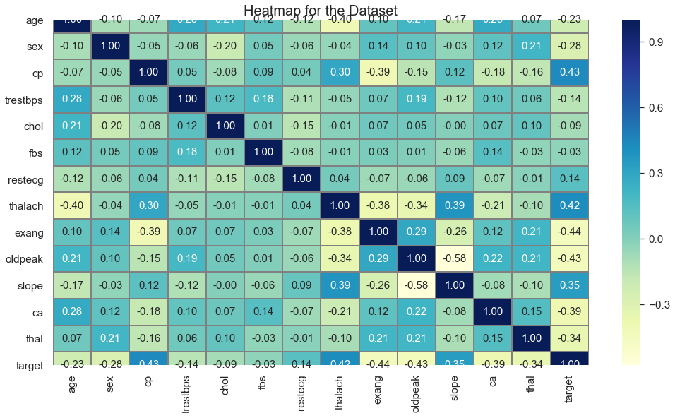

```python
# Drawing a heat map

plt.rcParams['figure.figsize'] = (17, 9)
plt.style.use('ggplot')
sns.set(font_scale=1.4)
sns.heatmap(data.corr(), annot = True, annot_kws={"size": 15}, fmt='.2f', cmap = 'YlGnBu', linewidths=1, linecolor='gray')
plt.title('Heatmap for the Dataset', fontsize = 20, fontweight=30)
plt.yticks(rotation=0)
plt.xticks(rotation=90)
plt.show()
```

> It can be seen that almost all of the features/attributes given in the dataset are very less correlated with each other. This implies we must include all of the features, as we can only eliminate those features where the correlation of two or more features are very high.

### DIstributions of the attributes

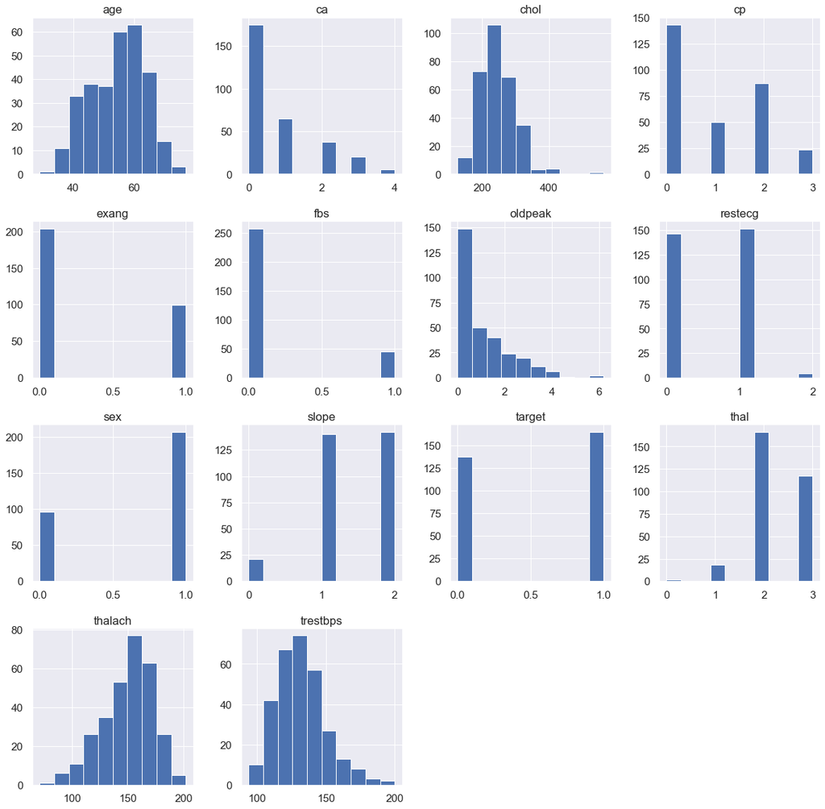

```python
# checking the distribution of the featurres in the dataset

plt.figure(figsize=(20,20))
data.hist(figsize=(20,20))
plt.show()
```

> From the histograms above, Each feature has a different range of distribution. Thus, Normalizing the data before our predictions should be of great use. Also note that the categorical features do stand out.

> It's always a good practice to work with a dataset where the target classes are of approximately equal size. Thus, let's check for the same.

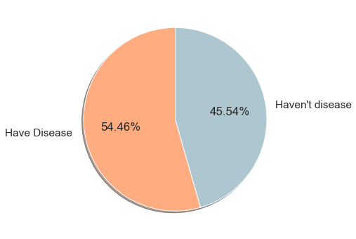

```python
# plotting the target attribute

disease = len(data[data['target'] == 1])
non_disease = len(data[data['target'] == 0])
plt.pie(x=[disease, non_disease], explode=(0, 0), labels=['Have Disease ', 'Haven\'t disease'],autopct='%1.2f%%' ,
        shadow=True, startangle=90,colors = ['#ffac81','#aec6cf'])
fig = plt.gcf()
fig.set_size_inches(6,6)
plt.show()
```

> Looking at the Distribution of Target, The dataset is quite balanced with almost equal no. of Positive and Negative Classes. The two classes are not exactly 50% each but the ratio is good enough to continue without dropping/increasing our data.